# hw05

Cody Grainger

14 July 2020

```r
library(tidyverse)
```

### Plot 1

Trees Scatter plot

Scatterplot displaying the trees dataset

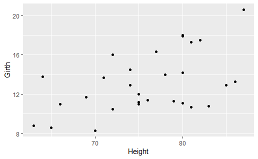

```r
data(trees)
?trees
ggplot(data=trees)+
  geom_point(mapping=aes(x=Height,y=Girth))
```

### Plot 2

Lynx Linegraph

a linegraph for the lynx data set with the color set to Maroon

```r
data(lynx)
?lynx

#creating a vector for years 1821-1934
year <- c(1821:1934)
year
```

```
  [1] 1821 1822 1823 1824 1825 1826 1827 1828 1829 1830 1831
 [12] 1832 1833 1834 1835 1836 1837 1838 1839 1840 1841 1842
 [23] 1843 1844 1845 1846 1847 1848 1849 1850 1851 1852 1853
 [34] 1854 1855 1856 1857 1858 1859 1860 1861 1862 1863 1864
 [45] 1865 1866 1867 1868 1869 1870 1871 1872 1873 1874 1875
 [56] 1876 1877 1878 1879 1880 1881 1882 1883 1884 1885 1886
 [67] 1887 1888 1889 1890 1891 1892 1893 1894 1895 1896 1897
 [78] 1898 1899 1900 1901 1902 1903 1904 1905 1906 1907 1908
 [89] 1909 1910 1911 1912 1913 1914 1915 1916 1917 1918 1919
[100] 1920 1921 1922 1923 1924 1925 1926 1927 1928 1929 1930
[111] 1931 1932 1933 1934
```

```r
#inspecting the class of the lynx data set
class(lynx)
```

```
[1] "ts"
```

```r
# the class is "time series"

#converting ts to vector
pelts <- as.vector(lynx)
pelts
```

```
  [1]  269  321  585  871 1475 2821 3928 5943 4950 2577  523
 [12]   98  184  279  409 2285 2685 3409 1824  409  151   45
 [23]   68  213  546 1033 2129 2536  957  361  377  225  360
 [34]  731 1638 2725 2871 2119  684  299  236  245  552 1623
 [45] 3311 6721 4254  687  255  473  358  784 1594 1676 2251
 [56] 1426  756  299  201  229  469  736 2042 2811 4431 2511
 [67]  389   73   39   49   59  188  377 1292 4031 3495  587
 [78]  105  153  387  758 1307 3465 6991 6313 3794 1836  345
 [89]  382  808 1388 2713 3800 3091 2985 3790  674   81   80
[100]  108  229  399 1132 2432 3574 2935 1537  529  485  662
[111] 1000 1590 2657 3396
```

```r
lynxDF <- data.frame(year,pelts)
lynxDF
```

| year | pelts |
| --- | --- |
| 1821 | 269 |
| 1822 | 321 |
| 1823 | 585 |
| 1824 | 871 |
| 1825 | 1475 |
| 1826 | 2821 |
| 1827 | 3928 |
| 1828 | 5943 |
| 1829 | 4950 |
| 1830 | 2577 |

[output cut: 104 more lines]

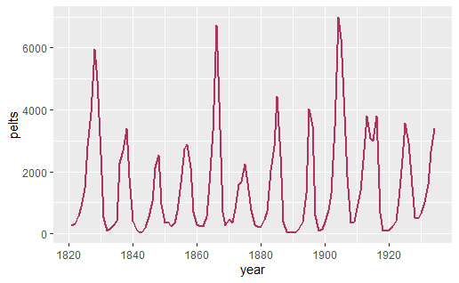

```r
ggplot(data=lynxDF)+
  geom_line(mapping=aes(x=year,y=pelts),color="Maroon",size=1)
```

### Plot 3

iris scatter plot

A scatter plot for the iris data set with manual labels set

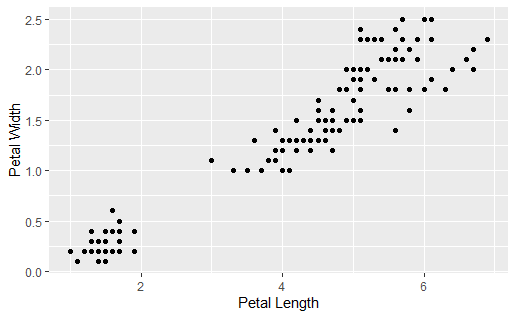

```r
data(iris)

?iris


ggplot(data=iris)+
  geom_point(mapping=aes(x=Petal.Length,y=Petal.Width)) +
  labs(x="Petal Length", y = "Petal Width")
```

### Plots 4 and 5

msleep Violin Plots

Violin plots use geometric shapes with varying widths throughout to represent data density. The widest part of any one violin plot object represents the median of the data set. The wider the figure the higher the density of data points that fall within those corresponding values

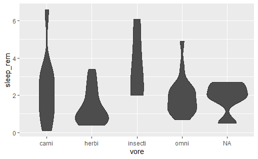

```r
data(msleep)
?msleep

ggplot(data=msleep) +
  geom_violin(mapping=aes(x=vore,y=sleep_rem),fill="gray30")
```

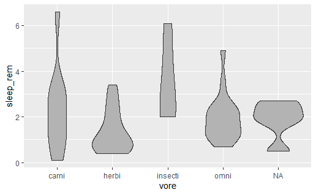

```r
ggplot(data=msleep) +
  geom_violin(mapping=aes(x=vore,y=sleep_rem),fill="gray70")
```

### Plot 7

msleep boxplots

A boxplot of the msleep data with the use or coord_flip

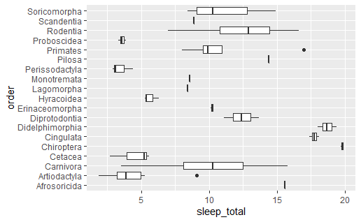

```r
ggplot(data=msleep)+
  geom_boxplot(mapping=aes(x=order,y=sleep_total))+
  coord_flip()
```

#### Plot 8

msleep boxplot with points

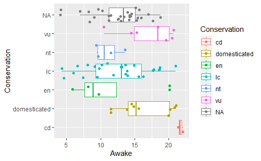

```r
ggplot(data=msleep)+
  aes(x=conservation,y=awake,color=conservation)+
  geom_boxplot()+
  geom_point(position="jitter")+
  coord_flip()+
  labs(x="Conservation",y="Awake",color="Conservation")
```

### Plots 9 and 10

#Plot 9 2 plots of the same data but with one showing individuals with a body weight less than 5 only to better view the bottom of the plots in the first plot

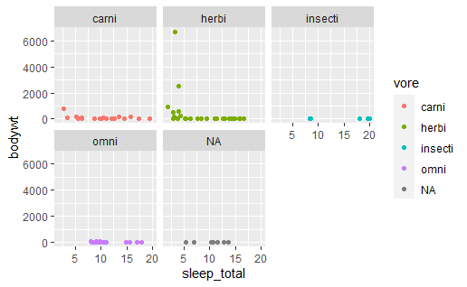

```r
?msleep

ggplot(data=msleep)+
  geom_point(mapping=aes(x=sleep_total,y=bodywt,color=vore),position="jitter")+
  facet_wrap(~vore,ncol=3)
```

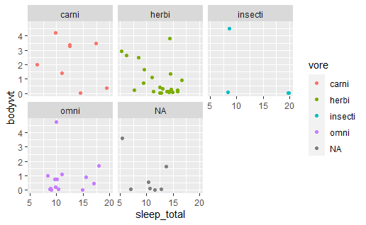

```r
# plot of all animals with a body weight less than 5. It was hard to see the points at the bottom of the graph
msleep2 <- msleep$bodywt <5
msleep3 <- msleep[msleep2,]
ggplot(data=msleep3)+
  geom_point(mapping=aes(x=sleep_total,y=bodywt,color=vore),position="jitter")+
  facet_wrap(~vore,ncol=3)
```

Herbivores seem to have greater body weights associated with less sleep. This seems to weakly apply to carnivores as well. The other categories dont seem to show much of a clear trend

#Plot 10

2 plots showing the same data but with facet_wrap applied to one

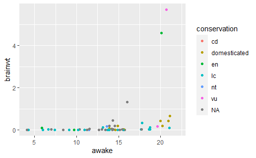

```r
data(msleep)

ggplot(data=msleep)+
  geom_point(mapping=aes(x=awake,y=brainwt,color=conservation),position="jitter")
```

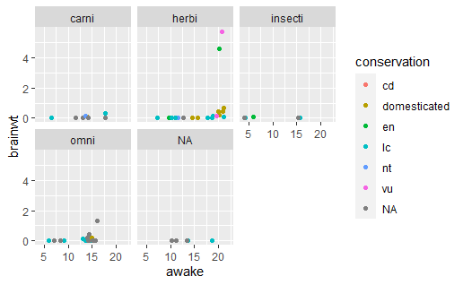

```r
ggplot(data=msleep)+
  geom_point(mapping=aes(x=awake,y=brainwt,color=conservation),position="jitter") +
  facet_wrap(~vore,ncol=3)
```

Herbivores in general seem to spend more time awake than insectivores and carnivores. omnivores seem to have a high concentration of individuals that are awake for around 15 hours. It would seem that more hours awake correllates with a higher brain weight.